# Using AeroSampleR to model aerosol sampling efficiency

## AeroSampleR Introduction

Air sampling systems are used in many applications that require the monitoring of hazardous airborne particles. When tubing is used to collect aerosol particles, some of the particles are lost along the way. The efficiency of the system depends on the particle and tubing configuration.

This version of AeroSampleR provides sampling efficiency for a limited set of system elements. Sampling systems always include a probe, after which are combinations of straight tubing and bends. While some systems include expansion or contraction elements, or sample splitters. These components are not covered in this version of AeroSampleR. The probe model is limited to a simple open ended pipe in still air.

AeroSampleR relies on the concept of aerodynamic median activity diameter (AMAD), which accounts for particle density and shape, leaving equivalent spherical water droplets as the modeling targets.

Efficiency functions are based predominantly on testing with aerosol particles through stainless steel tubing. The [Zhang](https://doi.org/10.1016/j.jaerosci.2012.05.007) and [Pui](https://doi.org/10.1080/02786828708959166) bend models are used in this package.

The aerosol transport models are based on tests on clean systems. This package is designed primarily for new tubing designs. If a system is not maintained clean – and free of condensation, there can be no expectation that sampling efficiency models will be accurate.

### example data

The first task in evaluating a system is to set up a table that includes all the “elements” with the following column headers:

- `el_num` sequential number of the element
- `el_type` starting with “probe”, followed by “tube” and “bend” elements
- `length_cm` length of tubes in centimeters. Leave blank for probe and bends.
- `angle_to_horiz` degree of slope of straight tube elements. Leave blank for probes and bends.
- `orient` orientation of the probe. Options are “u” for up, “d” for down and “h” for horizontal ``bend_angle` how many degrees a bend turns the sample. Typically, 90 or 45. Leave blank for probes and tubes.
- `bend_rad_cm` the bend radius in centimeters. Leave blank for probes and tubes.

| el_num | el_type | length_cm | angle_to_horiz | orient | bend_angle | bend_rad_cm |
| --- | --- | --- | --- | --- | --- | --- |
| 1 | probe |  |  | u |  |  |
| 2 | tube | 112 | 90 |  |  |  |
| 3 | bend |  |  |  | 90 | 13 |
| 4 | tube | 146 | 0 |  |  |  |

### 1) Get the system data

You need to get this data into R and call it `sys_df`, the “system” data frame. There are many options on how to do this. Below are two examples. You will have to provide the path and the file name, but for the example, we’ll show the file to be called system.txt or system.xlsx in `c:/work`. Here are two:

1. Use base R, (`utils` package that is loaded with base R) to read a text file:

```r
sys_df <- read.table(
  file = "c:/work/system.txt",
  header = TRUE
  )
```

2. Use the readxl package to read a spreadsheet of the ‘xlsx’ format:

```r
sys_df <- readxl::read_xlsx(path = "c:/work/system.xlsx",
           sheet = "Sheet1", #default - update if needed
           range = "A1:G5", #put in entire range
           col_types = c("numeric",
                         "text",
                         "numeric",
                         "numeric",
                         "text",
                         "numeric",
                         "numeric")
                            )
```

### 2) Create particle distribution with `particle_dist()`

This function provides a logarithmic distribution of 1000 particle sizes and an additional set of discrete particles. By default, the logarithmically-distributed particles have an AMAD of 5 and a lognormal standard deviation of 2.5, consistent with ICRP 66.

The discrete particles are 1, 5, and 10 micrometers AMAD.

```r
df <- particle_dist() #Default
```

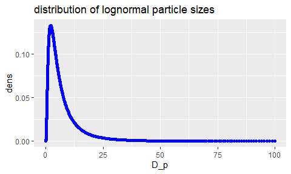

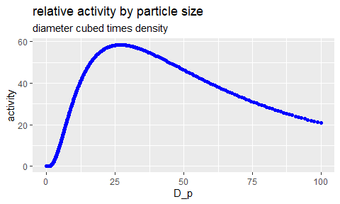